# Homework 1

Ishita Dutta

1/15/2022

# Getting Data Setup

```r
library(readxl)
cars <- read_excel("cars931.xlsx")
Y = log(cars[,1])
X1 = log(cars[,2])
X2 = log(cars[,3])
X3 = log(cars[,4])
X4 = sqrt(cars[,5])
X5 = cars[,6]
X6 = cars[,7]
```

#1a)

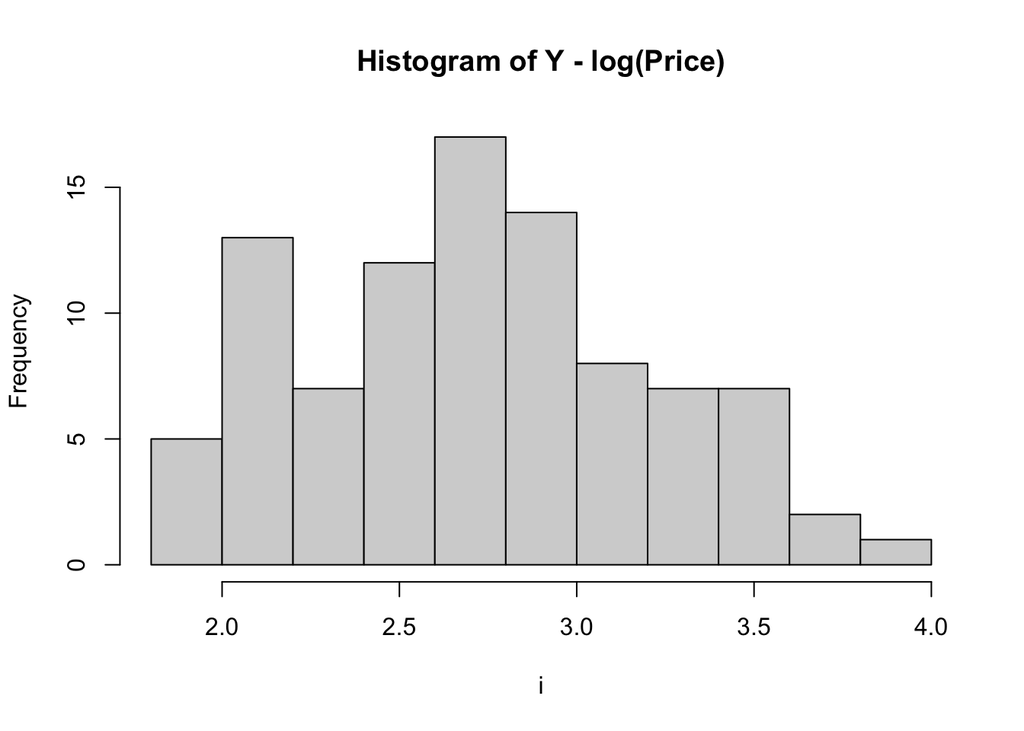

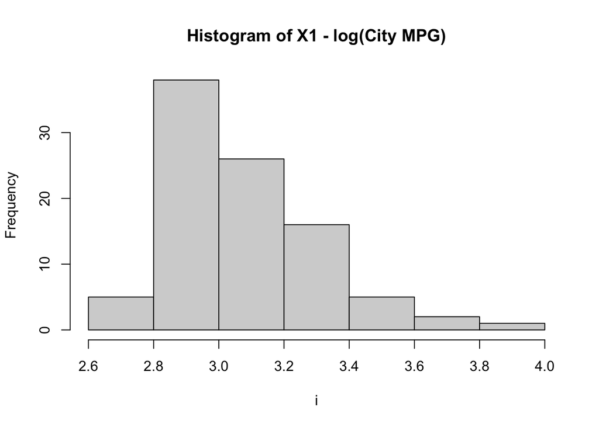

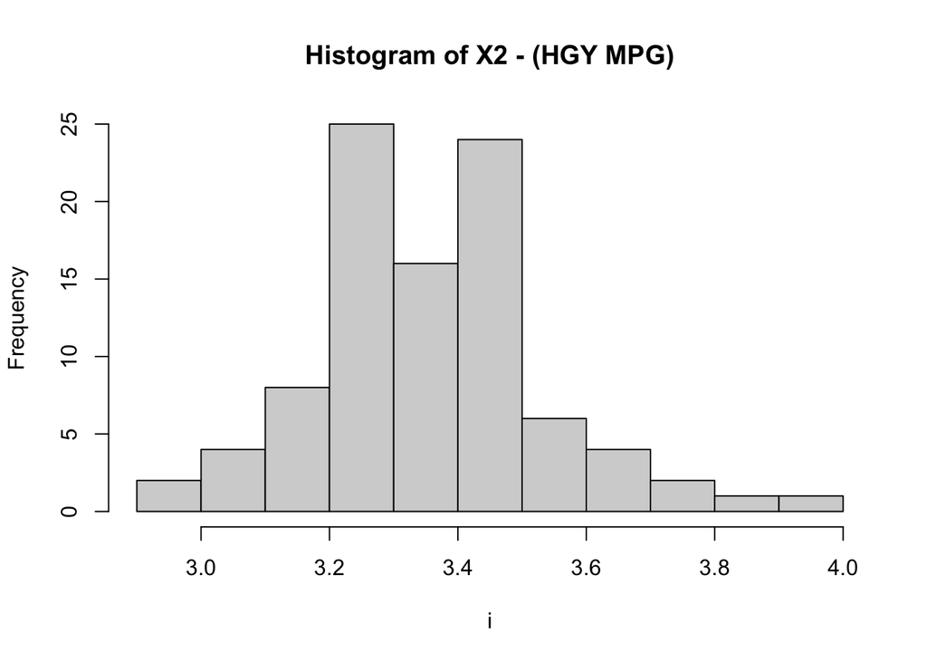

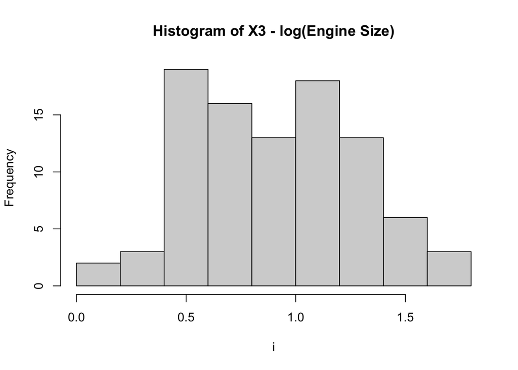

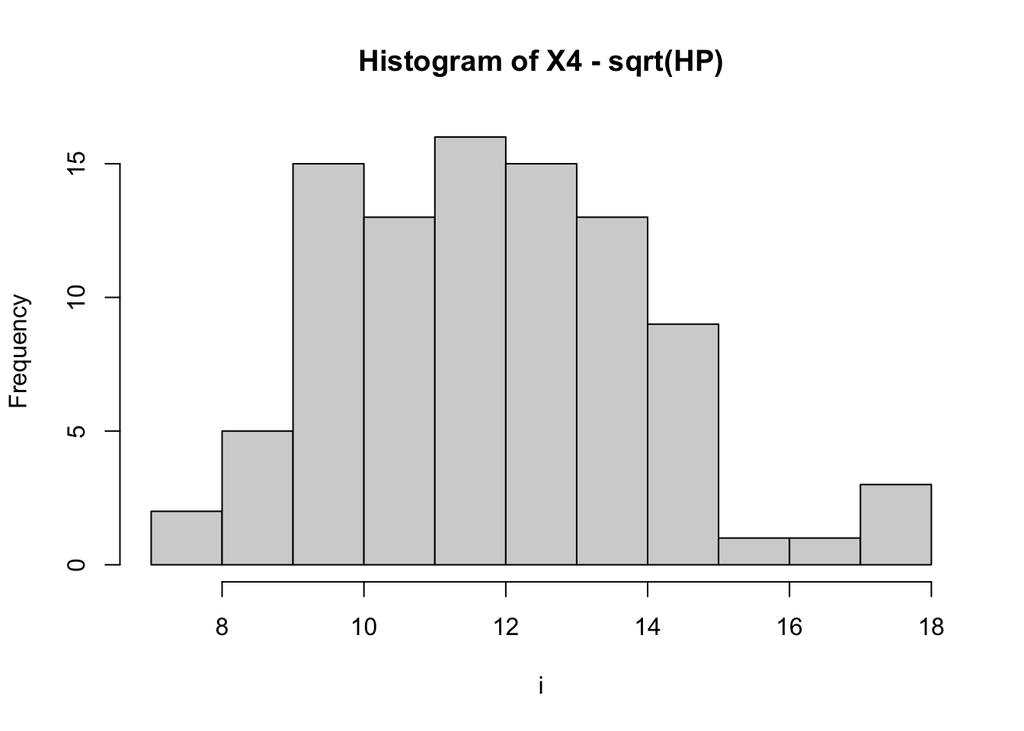

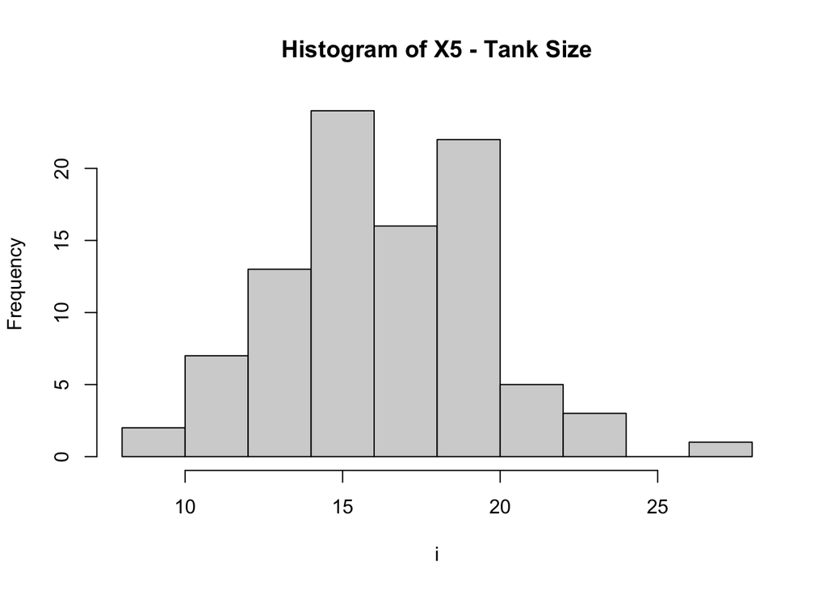

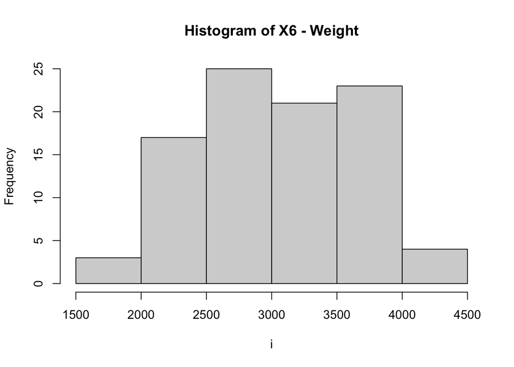

```r
columns = c(Y, X1, X2, X3, X4, X5, X6)
names = c("Y - log(Price)", "X1 - log(City MPG)", "X2 - (HGY MPG)", "X3 - log(Engine Size)", "X4 - sqrt(HP)", "X5 - Tank Size", "X6 - Weight")
counter = 1
for(i in columns) {
  hist(i, main = paste("Histogram of", names[counter]))
  counter = counter + 1
}
```

```r
counter = 1
```

#1b)

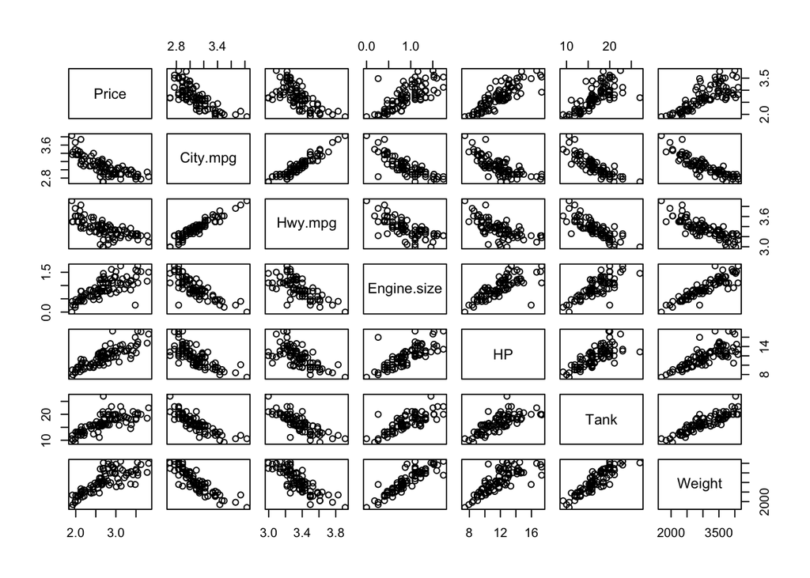

```r
carsframe = data.frame(Y, X1, X2, X3, X4, X5, X6)
pairs(carsframe)
```

```r
cor(carsframe)
```

```
##                  Price   City.mpg    Hwy.mpg Engine.size         HP       Tank
## Price        1.0000000 -0.7653709 -0.6771546   0.7334954  0.8421865  0.7309787
## City.mpg    -0.7653709  1.0000000  0.9348766  -0.8204781 -0.7531728 -0.8577268
## Hwy.mpg     -0.6771546  0.9348766  1.0000000  -0.7018325 -0.6609357 -0.8117215
## Engine.size  0.7334954 -0.8204781 -0.7018325   1.0000000  0.7692466  0.7964804
## HP           0.8421865 -0.7531728 -0.6609357   0.7692466  1.0000000  0.7458797
## Tank         0.7309787 -0.8577268 -0.8117215   0.7964804  0.7458797  1.0000000
## Weight       0.7710072 -0.8833464 -0.8281411   0.8971410  0.7799303  0.8940181
##                 Weight
## Price        0.7710072
## City.mpg    -0.8833464
## Hwy.mpg     -0.8281411
## Engine.size  0.8971410
## HP           0.7799303
## Tank         0.8940181
## Weight       1.0000000
```

*Answer:* The correlation matrix seems to suggest strong multicollinearity in between all of the variables and Y as well as between each other. These all need to be investigated further before building a model.

1c)

```r
reg1 = lm(formula  = carsframe[,1] ~ carsframe[,2] + carsframe[,3] + carsframe[,4] + carsframe[,5] + carsframe[,6] + carsframe[,7], data = carsframe)
summary(reg1)
```

```
##
## Call:
## lm(formula = carsframe[, 1] ~ carsframe[, 2] + carsframe[, 3] +
##     carsframe[, 4] + carsframe[, 5] + carsframe[, 6] + carsframe[,
##     7], data = carsframe)
##
## Residuals:
##      Min       1Q   Median       3Q      Max
## -0.69711 -0.15954 -0.00492  0.12869  0.64015
##
## Coefficients:
##                  Estimate Std. Error t value Pr(>|t|)
## (Intercept)     1.8118325  1.2249902   1.479   0.1428
## carsframe[, 2] -0.7831210  0.4408392  -1.776   0.0792 .
## carsframe[, 3]  0.4153257  0.4674927   0.888   0.3768
## carsframe[, 4] -0.0938671  0.1732330  -0.542   0.5893
## carsframe[, 5]  0.1303312  0.0207344   6.286  1.3e-08 ***
## carsframe[, 6] -0.0005864  0.0187063  -0.031   0.9751
## carsframe[, 7]  0.0001587  0.0001456   1.090   0.2787
## ---
## Signif. codes:  0 '***' 0.001 '**' 0.01 '*' 0.05 '.' 0.1 ' ' 1
##
## Residual standard error: 0.2463 on 86 degrees of freedom
## Multiple R-squared:  0.7545, Adjusted R-squared:  0.7374
## F-statistic: 44.06 on 6 and 86 DF,  p-value: < 2.2e-16
```

```r
anova(reg1)
```

```
## Analysis of Variance Table
##
## Response: carsframe[, 1]
##                Df  Sum Sq Mean Sq  F value    Pr(>F)
## carsframe[, 2]  1 12.4472 12.4472 205.2310 < 2.2e-16 ***
## carsframe[, 3]  1  0.2483  0.2483   4.0941  0.046139 *
## carsframe[, 4]  1  0.5321  0.5321   8.7730  0.003952 **
## carsframe[, 5]  1  2.7165  2.7165  44.7895 2.128e-09 ***
## carsframe[, 6]  1  0.0165  0.0165   0.2718  0.603484
## carsframe[, 7]  1  0.0721  0.0721   1.1882  0.278742
## Residuals      86  5.2159  0.0606
## ---
## Signif. codes:  0 '***' 0.001 '**' 0.01 '*' 0.05 '.' 0.1 ' ' 1
```

1d) I think not all the variables are needed for this regression model. In particular, the tank size and weight are not as necessary as the other variables as they do not seem to have as much of a significant P value in the ANOVA table. For this model, I would drop the tank size variable (X5) because it is the least significant variable in the ANOVA table.

2a)

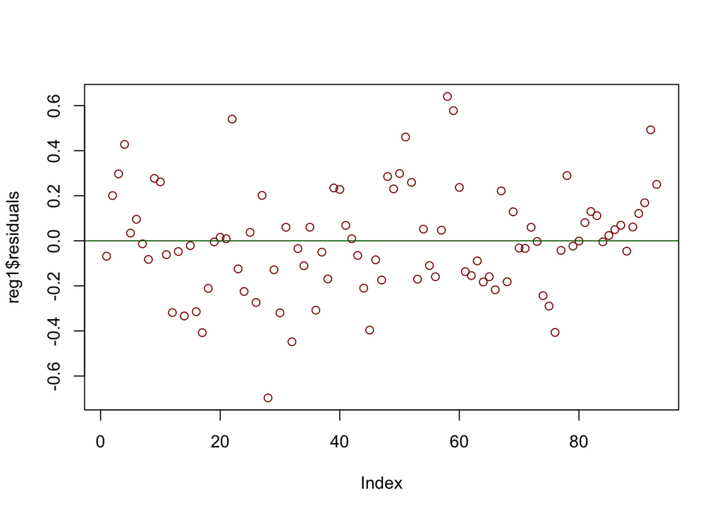

```r
plot(reg1$residuals, col = "dark red")
abline(h = 0, col = "dark green")
```

*Answer:* I feel that there should not be a problem here, as the scatterplot of the residuals seems to follow a rather normal distribution around the proposed regression line.

2c)

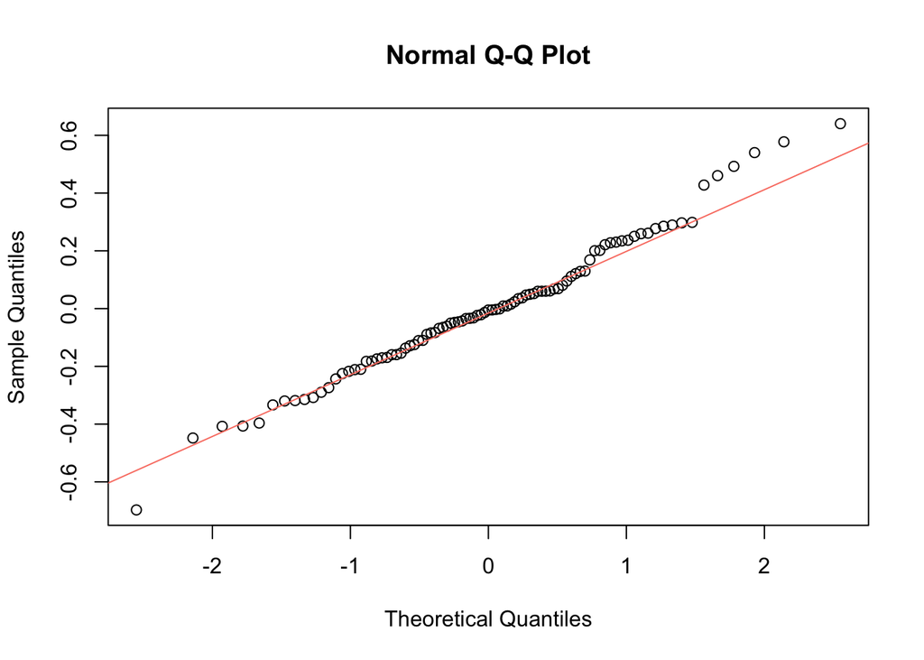

```r
qqnorm(reg1$residuals)
qqline(reg1$residuals, col = "salmon")
```

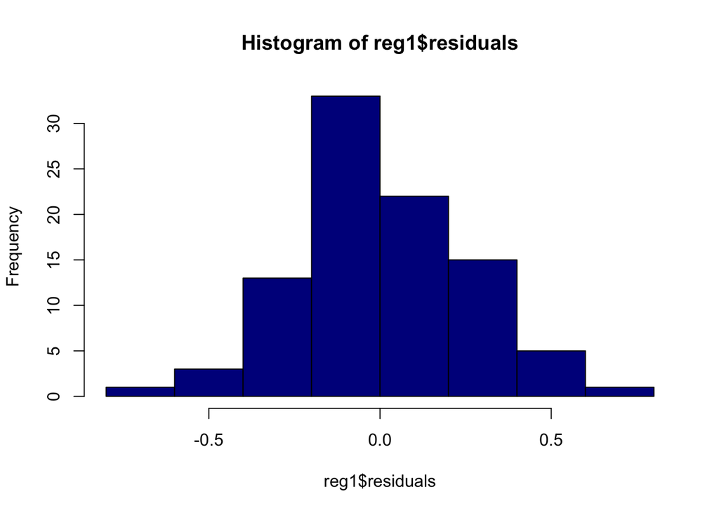

```r
hist(reg1$residuals, col = "dark blue", breaks = 8)
```

3a)

```r
step(reg1)
```

```
## Start:  AIC=-253.92
## carsframe[, 1] ~ carsframe[, 2] + carsframe[, 3] + carsframe[,
##     4] + carsframe[, 5] + carsframe[, 6] + carsframe[, 7]
##
##                  Df Sum of Sq    RSS     AIC
## - carsframe[, 6]  1   0.00006 5.2159 -255.92
## - carsframe[, 4]  1   0.01781 5.2337 -255.61
## - carsframe[, 3]  1   0.04787 5.2638 -255.07
## - carsframe[, 7]  1   0.07206 5.2879 -254.65
## <none>                        5.2159 -253.92
## - carsframe[, 2]  1   0.19139 5.4073 -252.57
## - carsframe[, 5]  1   2.39630 7.6122 -220.76
##
## Step:  AIC=-255.92
## carsframe[, 1] ~ carsframe[, 2] + carsframe[, 3] + carsframe[,
##     4] + carsframe[, 5] + carsframe[, 7]
##
##                  Df Sum of Sq    RSS     AIC
## - carsframe[, 4]  1   0.01776 5.2337 -257.61
## - carsframe[, 3]  1   0.04810 5.2640 -257.07
## - carsframe[, 7]  1   0.08849 5.3044 -256.36
## <none>                        5.2159 -255.92
## - carsframe[, 2]  1   0.19474 5.4107 -254.51
## - carsframe[, 5]  1   2.43855 7.6545 -222.25
##
## Step:  AIC=-257.61
## carsframe[, 1] ~ carsframe[, 2] + carsframe[, 3] + carsframe[,
##     5] + carsframe[, 7]
##
##                  Df Sum of Sq    RSS     AIC
## - carsframe[, 3]  1   0.03273 5.2664 -259.03
## - carsframe[, 7]  1   0.07576 5.3095 -258.27
## <none>                        5.2337 -257.61
## - carsframe[, 2]  1   0.17817 5.4119 -256.49
## - carsframe[, 5]  1   2.43470 7.6684 -224.08
##
## Step:  AIC=-259.03
## carsframe[, 1] ~ carsframe[, 2] + carsframe[, 5] + carsframe[,
##     7]
##
##                  Df Sum of Sq    RSS     AIC
## - carsframe[, 7]  1   0.06756 5.3340 -259.84
## <none>                        5.2664 -259.03
## - carsframe[, 2]  1   0.20402 5.4704 -257.49
## - carsframe[, 5]  1   2.66347 7.9299 -222.96
##
## Step:  AIC=-259.84
## carsframe[, 1] ~ carsframe[, 2] + carsframe[, 5]
##
##                  Df Sum of Sq    RSS     AIC
## <none>                        5.3340 -259.84
## - carsframe[, 2]  1    0.8434 6.1774 -248.19
## - carsframe[, 5]  1    3.4673 8.8013 -215.27
```

```
##
## Call:
## lm(formula = carsframe[, 1] ~ carsframe[, 2] + carsframe[, 5],
##     data = carsframe)
##
## Coefficients:
##    (Intercept)  carsframe[, 2]  carsframe[, 5]
##         3.0821         -0.6501          0.1393
```

3b)

```r
library(flexmix)
BIC(lm(carsframe[, 1] ~ carsframe[, 2] + carsframe[, 3] + carsframe[,
    4] + carsframe[, 5] + carsframe[, 6] + carsframe[, 7]))
```

```
## [1] 32.26046
```

```r
BIC(lm(carsframe[, 1] ~ carsframe[, 2] + carsframe[, 3] + carsframe[,
    4] + carsframe[, 5] + carsframe[, 7]))
```

```
## [1] 27.72892
```

```r
BIC(lm(carsframe[, 1] ~ carsframe[, 2] + carsframe[, 3] + carsframe[, 5] + carsframe[, 7]))
```

```
## [1] 23.51238
```

```r
BIC(lm(carsframe[, 1] ~ carsframe[, 2] + carsframe[, 5] + carsframe[, 7]))
```

```
## [1] 19.55958
```

```r
BIC(lm(carsframe[, 1] ~ carsframe[, 2] + carsframe[, 5]))
```

```
## [1] 16.21238
```

*Answer:* The last model, only taking X1 and X4, has the lowest constant, which means it should be the best model to use in this data set.

```r
reg2 = lm(carsframe[, 1] ~ carsframe[, 2] + carsframe[, 5])
summary(reg2)
```

```
##
## Call:
## lm(formula = carsframe[, 1] ~ carsframe[, 2] + carsframe[, 5])
##
## Residuals:
##      Min       1Q   Median       3Q      Max
## -0.69811 -0.15300 -0.01137  0.14849  0.64441
##
## Coefficients:
##                Estimate Std. Error t value Pr(>|t|)
## (Intercept)     3.08212    0.70764   4.356 3.51e-05 ***
## carsframe[, 2] -0.65010    0.17233  -3.772 0.000289 ***
## carsframe[, 5]  0.13930    0.01821   7.649 2.15e-11 ***
## ---
## Signif. codes:  0 '***' 0.001 '**' 0.01 '*' 0.05 '.' 0.1 ' ' 1
##
## Residual standard error: 0.2434 on 90 degrees of freedom
## Multiple R-squared:  0.749,  Adjusted R-squared:  0.7434
## F-statistic: 134.3 on 2 and 90 DF,  p-value: < 2.2e-16
```

```r
anova(reg2)
```

```
## Analysis of Variance Table
##
## Response: carsframe[, 1]
##                Df  Sum Sq Mean Sq F value    Pr(>F)
## carsframe[, 2]  1 12.4472 12.4472 210.021 < 2.2e-16 ***
## carsframe[, 5]  1  3.4673  3.4673  58.504 2.146e-11 ***
## Residuals      90  5.3340  0.0593
## ---
## Signif. codes:  0 '***' 0.001 '**' 0.01 '*' 0.05 '.' 0.1 ' ' 1
```

Both criterion point to this model as the best for this data set.